# Risk Factor Analysis

## Outcome Variable

**Outcome Variable:** ever_wasted

## Predictor Variables

**Intervention Variable:** fage

**Adjustment Set:**

- arm
- W_mage
- meducyrs
- feducyrs
- W_mhtcm
- W_mwtkg
- W_mbmi
- W_fhtcm
- single
- brthmon
- delta_W_mage
- delta_meducyrs
- delta_feducyrs
- delta_W_mhtcm
- delta_W_mwtkg
- delta_W_mbmi
- delta_W_fhtcm
- delta_single
- delta_brthmon

## Stratifying Variables

The analysis was stratified on these variable(s):

- agecat
- studyid
- country

## Data Summary

| agecat | studyid | country | fage | ever_wasted | n_cell | n |
| --- | --- | --- | --- | --- | --- | --- |
| 0-24 months | ki0047075b-MAL-ED | BANGLADESH | >=38 | 0 | 46 | 151 |
| 0-24 months | ki0047075b-MAL-ED | BANGLADESH | >=38 | 1 | 23 | 151 |
| 0-24 months | ki0047075b-MAL-ED | BANGLADESH | <32 | 0 | 15 | 151 |
| 0-24 months | ki0047075b-MAL-ED | BANGLADESH | <32 | 1 | 15 | 151 |
| 0-24 months | ki0047075b-MAL-ED | BANGLADESH | [32-38) | 0 | 39 | 151 |
| 0-24 months | ki0047075b-MAL-ED | BANGLADESH | [32-38) | 1 | 13 | 151 |
| 0-24 months | ki0047075b-MAL-ED | BRAZIL | >=38 | 0 | 30 | 79 |
| 0-24 months | ki0047075b-MAL-ED | BRAZIL | >=38 | 1 | 0 | 79 |
| 0-24 months | ki0047075b-MAL-ED | BRAZIL | <32 | 0 | 16 | 79 |
| 0-24 months | ki0047075b-MAL-ED | BRAZIL | <32 | 1 | 2 | 79 |
| 0-24 months | ki0047075b-MAL-ED | BRAZIL | [32-38) | 0 | 28 | 79 |
| 0-24 months | ki0047075b-MAL-ED | BRAZIL | [32-38) | 1 | 3 | 79 |
| 0-24 months | ki0047075b-MAL-ED | INDIA | >=38 | 0 | 25 | 161 |
| 0-24 months | ki0047075b-MAL-ED | INDIA | >=38 | 1 | 11 | 161 |
| 0-24 months | ki0047075b-MAL-ED | INDIA | <32 | 0 | 20 | 161 |
| 0-24 months | ki0047075b-MAL-ED | INDIA | <32 | 1 | 33 | 161 |
| 0-24 months | ki0047075b-MAL-ED | INDIA | [32-38) | 0 | 36 | 161 |
| 0-24 months | ki0047075b-MAL-ED | INDIA | [32-38) | 1 | 36 | 161 |
| 0-24 months | ki0047075b-MAL-ED | NEPAL | >=38 | 0 | 13 | 79 |
| 0-24 months | ki0047075b-MAL-ED | NEPAL | >=38 | 1 | 4 | 79 |
| 0-24 months | ki0047075b-MAL-ED | NEPAL | <32 | 0 | 8 | 79 |
| 0-24 months | ki0047075b-MAL-ED | NEPAL | <32 | 1 | 7 | 79 |
| 0-24 months | ki0047075b-MAL-ED | NEPAL | [32-38) | 0 | 34 | 79 |
| 0-24 months | ki0047075b-MAL-ED | NEPAL | [32-38) | 1 | 13 | 79 |
| 0-24 months | ki0047075b-MAL-ED | PERU | >=38 | 0 | 26 | 85 |
| 0-24 months | ki0047075b-MAL-ED | PERU | >=38 | 1 | 1 | 85 |
| 0-24 months | ki0047075b-MAL-ED | PERU | <32 | 0 | 25 | 85 |
| 0-24 months | ki0047075b-MAL-ED | PERU | <32 | 1 | 4 | 85 |
| 0-24 months | ki0047075b-MAL-ED | PERU | [32-38) | 0 | 26 | 85 |
| 0-24 months | ki0047075b-MAL-ED | PERU | [32-38) | 1 | 3 | 85 |

[output cut: 204 more lines]

The following strata were considered:

- agecat: 0-24 months, studyid: ki0047075b-MAL-ED, country: BANGLADESH
- agecat: 0-24 months, studyid: ki0047075b-MAL-ED, country: BRAZIL
- agecat: 0-24 months, studyid: ki0047075b-MAL-ED, country: INDIA
- agecat: 0-24 months, studyid: ki0047075b-MAL-ED, country: NEPAL
- agecat: 0-24 months, studyid: ki0047075b-MAL-ED, country: PERU
- agecat: 0-24 months, studyid: ki0047075b-MAL-ED, country: SOUTH AFRICA
- agecat: 0-24 months, studyid: ki0047075b-MAL-ED, country: TANZANIA, UNITED REPUBLIC OF
- agecat: 0-24 months, studyid: ki1000304b-SAS-CompFeed, country: INDIA
- agecat: 0-24 months, studyid: ki1000304b-SAS-FoodSuppl, country: INDIA
- agecat: 0-24 months, studyid: ki1119695-PROBIT, country: BELARUS
- agecat: 0-24 months, studyid: ki1135781-COHORTS, country: GUATEMALA
- agecat: 0-24 months, studyid: ki1135781-COHORTS, country: PHILIPPINES
- agecat: 0-24 months, studyid: ki1148112-LCNI-5, country: MALAWI
- agecat: 0-6 months, studyid: ki0047075b-MAL-ED, country: BANGLADESH
- agecat: 0-6 months, studyid: ki0047075b-MAL-ED, country: BRAZIL
- agecat: 0-6 months, studyid: ki0047075b-MAL-ED, country: INDIA
- agecat: 0-6 months, studyid: ki0047075b-MAL-ED, country: NEPAL
- agecat: 0-6 months, studyid: ki0047075b-MAL-ED, country: PERU
- agecat: 0-6 months, studyid: ki0047075b-MAL-ED, country: SOUTH AFRICA
- agecat: 0-6 months, studyid: ki0047075b-MAL-ED, country: TANZANIA, UNITED REPUBLIC OF
- agecat: 0-6 months, studyid: ki1000304b-SAS-CompFeed, country: INDIA
- agecat: 0-6 months, studyid: ki1000304b-SAS-FoodSuppl, country: INDIA
- agecat: 0-6 months, studyid: ki1119695-PROBIT, country: BELARUS
- agecat: 0-6 months, studyid: ki1135781-COHORTS, country: GUATEMALA
- agecat: 0-6 months, studyid: ki1135781-COHORTS, country: PHILIPPINES
- agecat: 0-6 months, studyid: ki1148112-LCNI-5, country: MALAWI
- agecat: 6-24 months, studyid: ki0047075b-MAL-ED, country: BANGLADESH
- agecat: 6-24 months, studyid: ki0047075b-MAL-ED, country: BRAZIL
- agecat: 6-24 months, studyid: ki0047075b-MAL-ED, country: INDIA
- agecat: 6-24 months, studyid: ki0047075b-MAL-ED, country: NEPAL
- agecat: 6-24 months, studyid: ki0047075b-MAL-ED, country: PERU
- agecat: 6-24 months, studyid: ki0047075b-MAL-ED, country: SOUTH AFRICA
- agecat: 6-24 months, studyid: ki0047075b-MAL-ED, country: TANZANIA, UNITED REPUBLIC OF
- agecat: 6-24 months, studyid: ki1000304b-SAS-CompFeed, country: INDIA
- agecat: 6-24 months, studyid: ki1000304b-SAS-FoodSuppl, country: INDIA
- agecat: 6-24 months, studyid: ki1119695-PROBIT, country: BELARUS
- agecat: 6-24 months, studyid: ki1135781-COHORTS, country: GUATEMALA
- agecat: 6-24 months, studyid: ki1135781-COHORTS, country: PHILIPPINES
- agecat: 6-24 months, studyid: ki1148112-LCNI-5, country: MALAWI

### Dropped Strata

Some strata were dropped due to rare outcomes:

- agecat: 0-24 months, studyid: ki0047075b-MAL-ED, country: BRAZIL
- agecat: 0-24 months, studyid: ki0047075b-MAL-ED, country: NEPAL
- agecat: 0-24 months, studyid: ki0047075b-MAL-ED, country: PERU
- agecat: 0-24 months, studyid: ki0047075b-MAL-ED, country: SOUTH AFRICA
- agecat: 0-24 months, studyid: ki0047075b-MAL-ED, country: TANZANIA, UNITED REPUBLIC OF
- agecat: 0-24 months, studyid: ki1148112-LCNI-5, country: MALAWI
- agecat: 0-6 months, studyid: ki0047075b-MAL-ED, country: BRAZIL
- agecat: 0-6 months, studyid: ki0047075b-MAL-ED, country: NEPAL
- agecat: 0-6 months, studyid: ki0047075b-MAL-ED, country: PERU
- agecat: 0-6 months, studyid: ki0047075b-MAL-ED, country: SOUTH AFRICA
- agecat: 0-6 months, studyid: ki0047075b-MAL-ED, country: TANZANIA, UNITED REPUBLIC OF
- agecat: 0-6 months, studyid: ki1148112-LCNI-5, country: MALAWI
- agecat: 6-24 months, studyid: ki0047075b-MAL-ED, country: BRAZIL
- agecat: 6-24 months, studyid: ki0047075b-MAL-ED, country: NEPAL
- agecat: 6-24 months, studyid: ki0047075b-MAL-ED, country: PERU
- agecat: 6-24 months, studyid: ki0047075b-MAL-ED, country: SOUTH AFRICA
- agecat: 6-24 months, studyid: ki0047075b-MAL-ED, country: TANZANIA, UNITED REPUBLIC OF
- agecat: 6-24 months, studyid: ki1148112-LCNI-5, country: MALAWI

## Methods Detail

We’re interested in the causal parameters $E[Y_a]$ for all values of $a \in \mathcal{A}$. These parameters represent the mean outcome if, possibly contrary to fact, we intervened to set all units to have $A=a$. Under the randomization and positivity assumptions, these are identified by the statistical parameters $\psi_a=E_W[E_{Y|A,W}(Y|A=a,W)]$. In addition, we’re interested in the mean of $Y$, $E[Y]$ under no intervention (the observed mean). We will estimate these parameters by using SuperLearner to fit the relevant likelihood factors – $E_{Y|A,W}(Y|A=a,W)$ and $p(A=a|W)$, and then updating our likelihood fit using a joint TMLE.

For unadjusted analyses ($W=\{\}$), initial likelihoods were estimated using Lrnr_glm to estimate the simple $E(Y|A)$ and Lrnr_mean to estimate $p(A)$. For adjusted analyses, a small library containing Lrnr_glmnet, Lrnr_xgboost, and Lrnr_mean was used.

Having estimated these parameters, we will then use the delta method to estimate relative risks and attributable risks relative to a prespecified baseline level of $A$.

# Results Detail

## Results Plots

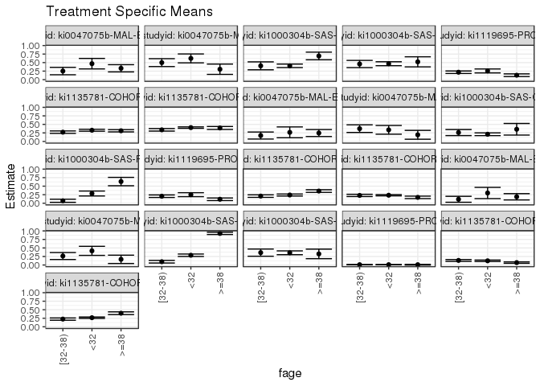

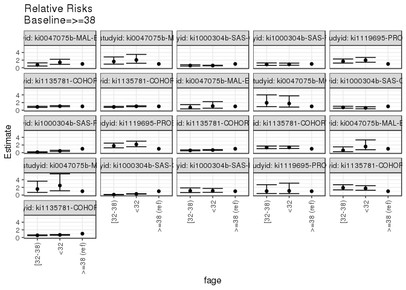

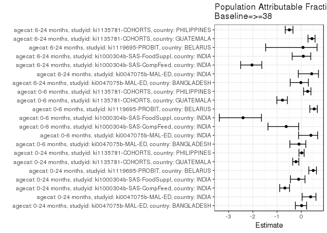

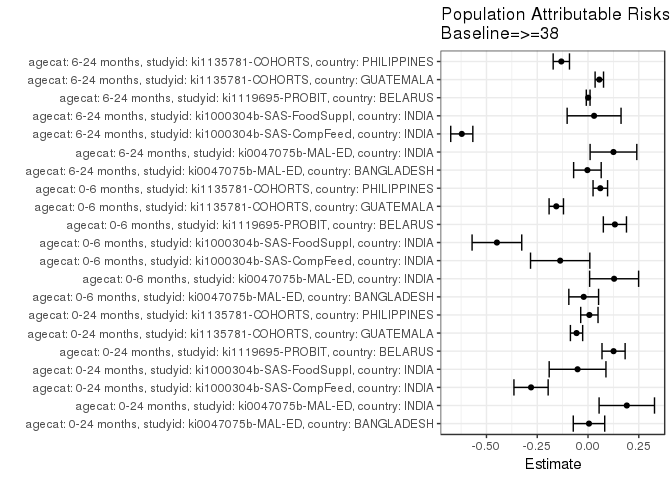

## Results Table

### Parameter: TSM

| agecat | studyid | country | intervention_level | baseline_level | estimate | ci_lower | ci_upper |
| --- | --- | --- | --- | --- | --- | --- | --- |
| 0-24 months | ki0047075b-MAL-ED | BANGLADESH | >=38 | NA | 0.3329203 | 0.2273850 | 0.4384556 |
| 0-24 months | ki0047075b-MAL-ED | BANGLADESH | <32 | NA | 0.4686353 | 0.3151304 | 0.6221402 |
| 0-24 months | ki0047075b-MAL-ED | BANGLADESH | [32-38) | NA | 0.2521970 | 0.1438961 | 0.3604978 |
| 0-24 months | ki0047075b-MAL-ED | INDIA | >=38 | NA | 0.3059146 | 0.1548896 | 0.4569395 |
| 0-24 months | ki0047075b-MAL-ED | INDIA | <32 | NA | 0.6230043 | 0.4922894 | 0.7537192 |
| 0-24 months | ki0047075b-MAL-ED | INDIA | [32-38) | NA | 0.4995010 | 0.3836091 | 0.6153928 |
| 0-24 months | ki1000304b-SAS-CompFeed | INDIA | >=38 | NA | 0.6950708 | 0.5828643 | 0.8072773 |
| 0-24 months | ki1000304b-SAS-CompFeed | INDIA | <32 | NA | 0.4057421 | 0.3545291 | 0.4569551 |
| 0-24 months | ki1000304b-SAS-CompFeed | INDIA | [32-38) | NA | 0.4051556 | 0.2888161 | 0.5214950 |
| 0-24 months | ki1000304b-SAS-FoodSuppl | INDIA | >=38 | NA | 0.5227273 | 0.3749653 | 0.6704893 |
| 0-24 months | ki1000304b-SAS-FoodSuppl | INDIA | <32 | NA | 0.4671280 | 0.4095378 | 0.5247182 |
| 0-24 months | ki1000304b-SAS-FoodSuppl | INDIA | [32-38) | NA | 0.4588235 | 0.3527637 | 0.5648834 |
| 0-24 months | ki1119695-PROBIT | BELARUS | >=38 | NA | 0.1296318 | 0.0899306 | 0.1693329 |
| 0-24 months | ki1119695-PROBIT | BELARUS | <32 | NA | 0.2556624 | 0.1977412 | 0.3135837 |
| 0-24 months | ki1119695-PROBIT | BELARUS | [32-38) | NA | 0.2177032 | 0.1809935 | 0.2544130 |
| 0-24 months | ki1135781-COHORTS | GUATEMALA | >=38 | NA | 0.3125453 | 0.2802006 | 0.3448900 |
| 0-24 months | ki1135781-COHORTS | GUATEMALA | <32 | NA | 0.3284834 | 0.3002180 | 0.3567488 |
| 0-24 months | ki1135781-COHORTS | GUATEMALA | [32-38) | NA | 0.2718594 | 0.2365054 | 0.3072135 |
| 0-24 months | ki1135781-COHORTS | PHILIPPINES | >=38 | NA | 0.3951621 | 0.3522157 | 0.4381085 |
| 0-24 months | ki1135781-COHORTS | PHILIPPINES | <32 | NA | 0.4059074 | 0.3843193 | 0.4274954 |
| 0-24 months | ki1135781-COHORTS | PHILIPPINES | [32-38) | NA | 0.3405517 | 0.3035317 | 0.3775718 |
| 0-6 months | ki0047075b-MAL-ED | BANGLADESH | >=38 | NA | 0.2463768 | 0.1443667 | 0.3483870 |
| 0-6 months | ki0047075b-MAL-ED | BANGLADESH | <32 | NA | 0.2666667 | 0.1078978 | 0.4254355 |
| 0-6 months | ki0047075b-MAL-ED | BANGLADESH | [32-38) | NA | 0.1730769 | 0.0699098 | 0.2762441 |
| 0-6 months | ki0047075b-MAL-ED | INDIA | >=38 | NA | 0.1944444 | 0.0647578 | 0.3241311 |
| 0-6 months | ki0047075b-MAL-ED | INDIA | <32 | NA | 0.3396226 | 0.2117265 | 0.4675188 |
| 0-6 months | ki0047075b-MAL-ED | INDIA | [32-38) | NA | 0.3750000 | 0.2628265 | 0.4871735 |
| 0-6 months | ki1000304b-SAS-CompFeed | INDIA | >=38 | NA | 0.3567315 | 0.1862417 | 0.5272213 |
| 0-6 months | ki1000304b-SAS-CompFeed | INDIA | <32 | NA | 0.2110842 | 0.1713753 | 0.2507930 |
| 0-6 months | ki1000304b-SAS-CompFeed | INDIA | [32-38) | NA | 0.2605995 | 0.1718061 | 0.3493929 |
| 0-6 months | ki1000304b-SAS-FoodSuppl | INDIA | >=38 | NA | 0.6351882 | 0.5119692 | 0.7584072 |
| 0-6 months | ki1000304b-SAS-FoodSuppl | INDIA | <32 | NA | 0.2845289 | 0.2123866 | 0.3566712 |
| 0-6 months | ki1000304b-SAS-FoodSuppl | INDIA | [32-38) | NA | 0.0720122 | 0.0260908 | 0.1179336 |
| 0-6 months | ki1119695-PROBIT | BELARUS | >=38 | NA | 0.1161182 | 0.0778129 | 0.1544235 |
| 0-6 months | ki1119695-PROBIT | BELARUS | <32 | NA | 0.2501810 | 0.1915884 | 0.3087735 |
| 0-6 months | ki1119695-PROBIT | BELARUS | [32-38) | NA | 0.2058987 | 0.1688645 | 0.2429330 |
| 0-6 months | ki1135781-COHORTS | GUATEMALA | >=38 | NA | 0.3568264 | 0.3178796 | 0.3957732 |
| 0-6 months | ki1135781-COHORTS | GUATEMALA | <32 | NA | 0.2410568 | 0.2115154 | 0.2705981 |
| 0-6 months | ki1135781-COHORTS | GUATEMALA | [32-38) | NA | 0.2092654 | 0.1714994 | 0.2470315 |
| 0-6 months | ki1135781-COHORTS | PHILIPPINES | >=38 | NA | 0.1715576 | 0.1358128 | 0.2073023 |
| 0-6 months | ki1135781-COHORTS | PHILIPPINES | <32 | NA | 0.2342480 | 0.2157597 | 0.2527364 |
| 0-6 months | ki1135781-COHORTS | PHILIPPINES | [32-38) | NA | 0.2290751 | 0.1958676 | 0.2622825 |
| 6-24 months | ki0047075b-MAL-ED | BANGLADESH | >=38 | NA | 0.1884058 | 0.0958331 | 0.2809785 |
| 6-24 months | ki0047075b-MAL-ED | BANGLADESH | <32 | NA | 0.3000000 | 0.1354719 | 0.4645281 |
| 6-24 months | ki0047075b-MAL-ED | BANGLADESH | [32-38) | NA | 0.1153846 | 0.0282601 | 0.2025091 |
| 6-24 months | ki0047075b-MAL-ED | INDIA | >=38 | NA | 0.1666667 | 0.0445476 | 0.2887858 |
| 6-24 months | ki0047075b-MAL-ED | INDIA | <32 | NA | 0.4150943 | 0.2820246 | 0.5481641 |
| 6-24 months | ki0047075b-MAL-ED | INDIA | [32-38) | NA | 0.2638889 | 0.1617674 | 0.3660104 |
| 6-24 months | ki1000304b-SAS-CompFeed | INDIA | >=38 | NA | 0.9267662 | 0.8935858 | 0.9599465 |
| 6-24 months | ki1000304b-SAS-CompFeed | INDIA | <32 | NA | 0.2859035 | 0.2505656 | 0.3212414 |
| 6-24 months | ki1000304b-SAS-CompFeed | INDIA | [32-38) | NA | 0.0971428 | 0.0584607 | 0.1358249 |
| 6-24 months | ki1000304b-SAS-FoodSuppl | INDIA | >=38 | NA | 0.3257514 | 0.1856520 | 0.4658507 |
| 6-24 months | ki1000304b-SAS-FoodSuppl | INDIA | <32 | NA | 0.3583977 | 0.3020701 | 0.4147253 |
| 6-24 months | ki1000304b-SAS-FoodSuppl | INDIA | [32-38) | NA | 0.3625205 | 0.2571248 | 0.4679162 |
| 6-24 months | ki1119695-PROBIT | BELARUS | >=38 | NA | 0.0095238 | -0.0012136 | 0.0202612 |
| 6-24 months | ki1119695-PROBIT | BELARUS | <32 | NA | 0.0103833 | 0.0077464 | 0.0130202 |
| 6-24 months | ki1119695-PROBIT | BELARUS | [32-38) | NA | 0.0098039 | 0.0053467 | 0.0142611 |
| 6-24 months | ki1135781-COHORTS | GUATEMALA | >=38 | NA | 0.0705108 | 0.0501905 | 0.0908311 |
| 6-24 months | ki1135781-COHORTS | GUATEMALA | <32 | NA | 0.1232641 | 0.1015449 | 0.1449834 |
| 6-24 months | ki1135781-COHORTS | GUATEMALA | [32-38) | NA | 0.1344137 | 0.1069487 | 0.1618787 |
| 6-24 months | ki1135781-COHORTS | PHILIPPINES | >=38 | NA | 0.3976001 | 0.3569277 | 0.4382726 |
| 6-24 months | ki1135781-COHORTS | PHILIPPINES | <32 | NA | 0.2666289 | 0.2463398 | 0.2869180 |
| 6-24 months | ki1135781-COHORTS | PHILIPPINES | [32-38) | NA | 0.2260063 | 0.1928515 | 0.2591612 |

### Parameter: E(Y)

| agecat | studyid | country | intervention_level | baseline_level | estimate | ci_lower | ci_upper |
| --- | --- | --- | --- | --- | --- | --- | --- |
| 0-24 months | ki0047075b-MAL-ED | BANGLADESH | NA | NA | 0.3377483 | 0.2620632 | 0.4134335 |
| 0-24 months | ki0047075b-MAL-ED | INDIA | NA | NA | 0.4968944 | 0.4194215 | 0.5743673 |
| 0-24 months | ki1000304b-SAS-CompFeed | INDIA | NA | NA | 0.4145695 | 0.3576236 | 0.4715155 |
| 0-24 months | ki1000304b-SAS-FoodSuppl | INDIA | NA | NA | 0.4712919 | 0.4233811 | 0.5192026 |
| 0-24 months | ki1119695-PROBIT | BELARUS | NA | NA | 0.2554368 | 0.1979772 | 0.3128964 |
| 0-24 months | ki1135781-COHORTS | GUATEMALA | NA | NA | 0.2560311 | 0.2321591 | 0.2799032 |
| 0-24 months | ki1135781-COHORTS | PHILIPPINES | NA | NA | 0.4018374 | 0.3841095 | 0.4195652 |
| 0-6 months | ki0047075b-MAL-ED | BANGLADESH | NA | NA | 0.2251656 | 0.1583223 | 0.2920089 |
| 0-6 months | ki0047075b-MAL-ED | INDIA | NA | NA | 0.3229814 | 0.2505249 | 0.3954378 |
| 0-6 months | ki1000304b-SAS-CompFeed | INDIA | NA | NA | 0.2197071 | 0.1750081 | 0.2644060 |
| 0-6 months | ki1000304b-SAS-FoodSuppl | INDIA | NA | NA | 0.1866029 | 0.1492099 | 0.2239959 |
| 0-6 months | ki1119695-PROBIT | BELARUS | NA | NA | 0.2485407 | 0.1903207 | 0.3067607 |
| 0-6 months | ki1135781-COHORTS | GUATEMALA | NA | NA | 0.2005842 | 0.1760818 | 0.2250867 |
| 0-6 months | ki1135781-COHORTS | PHILIPPINES | NA | NA | 0.2321307 | 0.2168619 | 0.2473995 |
| 6-24 months | ki0047075b-MAL-ED | BANGLADESH | NA | NA | 0.1854305 | 0.1232352 | 0.2476257 |
| 6-24 months | ki0047075b-MAL-ED | INDIA | NA | NA | 0.2919255 | 0.2214783 | 0.3623726 |
| 6-24 months | ki1000304b-SAS-CompFeed | INDIA | NA | NA | 0.3051948 | 0.2633957 | 0.3469939 |
| 6-24 months | ki1000304b-SAS-FoodSuppl | INDIA | NA | NA | 0.3557214 | 0.3088651 | 0.4025777 |
| 6-24 months | ki1119695-PROBIT | BELARUS | NA | NA | 0.0102551 | 0.0075905 | 0.0129198 |
| 6-24 months | ki1135781-COHORTS | GUATEMALA | NA | NA | 0.1261803 | 0.1071047 | 0.1452559 |
| 6-24 months | ki1135781-COHORTS | PHILIPPINES | NA | NA | 0.2661765 | 0.2495644 | 0.2827886 |

### Parameter: RR

| agecat | studyid | country | intervention_level | baseline_level | estimate | ci_lower | ci_upper |
| --- | --- | --- | --- | --- | --- | --- | --- |
| 0-24 months | ki0047075b-MAL-ED | BANGLADESH | >=38 | >=38 | 1.0000000 | 1.0000000 | 1.0000000 |
| 0-24 months | ki0047075b-MAL-ED | BANGLADESH | <32 | >=38 | 1.4076501 | 0.8933134 | 2.2181229 |
| 0-24 months | ki0047075b-MAL-ED | BANGLADESH | [32-38) | >=38 | 0.7575295 | 0.4466129 | 1.2848954 |
| 0-24 months | ki0047075b-MAL-ED | INDIA | >=38 | >=38 | 1.0000000 | 1.0000000 | 1.0000000 |
| 0-24 months | ki0047075b-MAL-ED | INDIA | <32 | >=38 | 2.0365305 | 1.1911282 | 3.4819562 |
| 0-24 months | ki0047075b-MAL-ED | INDIA | [32-38) | >=38 | 1.6328120 | 0.9462284 | 2.8175809 |
| 0-24 months | ki1000304b-SAS-CompFeed | INDIA | >=38 | >=38 | 1.0000000 | 1.0000000 | 1.0000000 |
| 0-24 months | ki1000304b-SAS-CompFeed | INDIA | <32 | >=38 | 0.5837422 | 0.5193010 | 0.6561800 |
| 0-24 months | ki1000304b-SAS-CompFeed | INDIA | [32-38) | >=38 | 0.5828983 | 0.4308866 | 0.7885378 |
| 0-24 months | ki1000304b-SAS-FoodSuppl | INDIA | >=38 | >=38 | 1.0000000 | 1.0000000 | 1.0000000 |
| 0-24 months | ki1000304b-SAS-FoodSuppl | INDIA | <32 | >=38 | 0.8936362 | 0.6564907 | 1.2164464 |
| 0-24 months | ki1000304b-SAS-FoodSuppl | INDIA | [32-38) | >=38 | 0.8777494 | 0.6092361 | 1.2646066 |
| 0-24 months | ki1119695-PROBIT | BELARUS | >=38 | >=38 | 1.0000000 | 1.0000000 | 1.0000000 |
| 0-24 months | ki1119695-PROBIT | BELARUS | <32 | >=38 | 1.9722203 | 1.4450649 | 2.6916805 |
| 0-24 months | ki1119695-PROBIT | BELARUS | [32-38) | >=38 | 1.6793969 | 1.2269021 | 2.2987767 |
| 0-24 months | ki1135781-COHORTS | GUATEMALA | >=38 | >=38 | 1.0000000 | 1.0000000 | 1.0000000 |
| 0-24 months | ki1135781-COHORTS | GUATEMALA | <32 | >=38 | 1.0509945 | 0.9190380 | 1.2018976 |
| 0-24 months | ki1135781-COHORTS | GUATEMALA | [32-38) | >=38 | 0.8698242 | 0.7376926 | 1.0256225 |
| 0-24 months | ki1135781-COHORTS | PHILIPPINES | >=38 | >=38 | 1.0000000 | 1.0000000 | 1.0000000 |
| 0-24 months | ki1135781-COHORTS | PHILIPPINES | <32 | >=38 | 1.0271921 | 0.9101678 | 1.1592628 |
| 0-24 months | ki1135781-COHORTS | PHILIPPINES | [32-38) | >=38 | 0.8618027 | 0.7390510 | 1.0049427 |
| 0-6 months | ki0047075b-MAL-ED | BANGLADESH | >=38 | >=38 | 1.0000000 | 1.0000000 | 1.0000000 |
| 0-6 months | ki0047075b-MAL-ED | BANGLADESH | <32 | >=38 | 1.0823529 | 0.5241066 | 2.2352092 |
| 0-6 months | ki0047075b-MAL-ED | BANGLADESH | [32-38) | >=38 | 0.7024887 | 0.3399717 | 1.4515632 |
| 0-6 months | ki0047075b-MAL-ED | INDIA | >=38 | >=38 | 1.0000000 | 1.0000000 | 1.0000000 |
| 0-6 months | ki0047075b-MAL-ED | INDIA | <32 | >=38 | 1.7466307 | 0.8120101 | 3.7569961 |
| 0-6 months | ki0047075b-MAL-ED | INDIA | [32-38) | >=38 | 1.9285714 | 0.9284968 | 4.0058164 |
| 0-6 months | ki1000304b-SAS-CompFeed | INDIA | >=38 | >=38 | 1.0000000 | 1.0000000 | 1.0000000 |
| 0-6 months | ki1000304b-SAS-CompFeed | INDIA | <32 | >=38 | 0.5917173 | 0.3863263 | 0.9063047 |
| 0-6 months | ki1000304b-SAS-CompFeed | INDIA | [32-38) | >=38 | 0.7305201 | 0.5194347 | 1.0273853 |
| 0-6 months | ki1000304b-SAS-FoodSuppl | INDIA | >=38 | >=38 | 1.0000000 | 1.0000000 | 1.0000000 |
| 0-6 months | ki1000304b-SAS-FoodSuppl | INDIA | <32 | >=38 | 0.4479442 | 0.3231871 | 0.6208602 |
| 0-6 months | ki1000304b-SAS-FoodSuppl | INDIA | [32-38) | >=38 | 0.1133714 | 0.0578217 | 0.2222881 |
| 0-6 months | ki1119695-PROBIT | BELARUS | >=38 | >=38 | 1.0000000 | 1.0000000 | 1.0000000 |
| 0-6 months | ki1119695-PROBIT | BELARUS | <32 | >=38 | 2.1545376 | 1.5482859 | 2.9981749 |
| 0-6 months | ki1119695-PROBIT | BELARUS | [32-38) | >=38 | 1.7731828 | 1.2642398 | 2.4870101 |
| 0-6 months | ki1135781-COHORTS | GUATEMALA | >=38 | >=38 | 1.0000000 | 1.0000000 | 1.0000000 |
| 0-6 months | ki1135781-COHORTS | GUATEMALA | <32 | >=38 | 0.6755576 | 0.5726565 | 0.7969490 |
| 0-6 months | ki1135781-COHORTS | GUATEMALA | [32-38) | >=38 | 0.5864628 | 0.4753912 | 0.7234856 |
| 0-6 months | ki1135781-COHORTS | PHILIPPINES | >=38 | >=38 | 1.0000000 | 1.0000000 | 1.0000000 |
| 0-6 months | ki1135781-COHORTS | PHILIPPINES | <32 | >=38 | 1.3654194 | 1.0927335 | 1.7061526 |
| 0-6 months | ki1135781-COHORTS | PHILIPPINES | [32-38) | >=38 | 1.3352664 | 1.0359982 | 1.7209840 |
| 6-24 months | ki0047075b-MAL-ED | BANGLADESH | >=38 | >=38 | 1.0000000 | 1.0000000 | 1.0000000 |
| 6-24 months | ki0047075b-MAL-ED | BANGLADESH | <32 | >=38 | 1.5923077 | 0.7624990 | 3.3251767 |
| 6-24 months | ki0047075b-MAL-ED | BANGLADESH | [32-38) | >=38 | 0.6124260 | 0.2487773 | 1.5076363 |
| 6-24 months | ki0047075b-MAL-ED | INDIA | >=38 | >=38 | 1.0000000 | 1.0000000 | 1.0000000 |
| 6-24 months | ki0047075b-MAL-ED | INDIA | <32 | >=38 | 2.4905660 | 1.1193351 | 5.5416104 |
| 6-24 months | ki0047075b-MAL-ED | INDIA | [32-38) | >=38 | 1.5833333 | 0.6913573 | 3.6261201 |
| 6-24 months | ki1000304b-SAS-CompFeed | INDIA | >=38 | >=38 | 1.0000000 | 1.0000000 | 1.0000000 |
| 6-24 months | ki1000304b-SAS-CompFeed | INDIA | <32 | >=38 | 0.3084959 | 0.2711521 | 0.3509826 |
| 6-24 months | ki1000304b-SAS-CompFeed | INDIA | [32-38) | >=38 | 0.1048191 | 0.0706504 | 0.1555129 |
| 6-24 months | ki1000304b-SAS-FoodSuppl | INDIA | >=38 | >=38 | 1.0000000 | 1.0000000 | 1.0000000 |
| 6-24 months | ki1000304b-SAS-FoodSuppl | INDIA | <32 | >=38 | 1.1002185 | 0.6960271 | 1.7391290 |
| 6-24 months | ki1000304b-SAS-FoodSuppl | INDIA | [32-38) | >=38 | 1.1128749 | 0.6622440 | 1.8701422 |
| 6-24 months | ki1119695-PROBIT | BELARUS | >=38 | >=38 | 1.0000000 | 1.0000000 | 1.0000000 |
| 6-24 months | ki1119695-PROBIT | BELARUS | <32 | >=38 | 1.0902490 | 0.3822067 | 3.1099478 |
| 6-24 months | ki1119695-PROBIT | BELARUS | [32-38) | >=38 | 1.0294118 | 0.3913001 | 2.7081224 |
| 6-24 months | ki1135781-COHORTS | GUATEMALA | >=38 | >=38 | 1.0000000 | 1.0000000 | 1.0000000 |
| 6-24 months | ki1135781-COHORTS | GUATEMALA | <32 | >=38 | 1.7481596 | 1.2498797 | 2.4450849 |
| 6-24 months | ki1135781-COHORTS | GUATEMALA | [32-38) | >=38 | 1.9062854 | 1.3440183 | 2.7037758 |
| 6-24 months | ki1135781-COHORTS | PHILIPPINES | >=38 | >=38 | 1.0000000 | 1.0000000 | 1.0000000 |
| 6-24 months | ki1135781-COHORTS | PHILIPPINES | <32 | >=38 | 0.6705956 | 0.5904292 | 0.7616467 |
| 6-24 months | ki1135781-COHORTS | PHILIPPINES | [32-38) | >=38 | 0.5684262 | 0.4752628 | 0.6798519 |

### Parameter: PAR

| agecat | studyid | country | intervention_level | baseline_level | estimate | ci_lower | ci_upper |
| --- | --- | --- | --- | --- | --- | --- | --- |
| 0-24 months | ki0047075b-MAL-ED | BANGLADESH | >=38 | NA | 0.0048280 | -0.0725720 | 0.0822280 |
| 0-24 months | ki0047075b-MAL-ED | INDIA | >=38 | NA | 0.1909799 | 0.0545567 | 0.3274030 |
| 0-24 months | ki1000304b-SAS-CompFeed | INDIA | >=38 | NA | -0.2805013 | -0.3647198 | -0.1962827 |
| 0-24 months | ki1000304b-SAS-FoodSuppl | INDIA | >=38 | NA | -0.0514354 | -0.1911941 | 0.0883233 |
| 0-24 months | ki1119695-PROBIT | BELARUS | >=38 | NA | 0.1258050 | 0.0688669 | 0.1827431 |
| 0-24 months | ki1135781-COHORTS | GUATEMALA | >=38 | NA | -0.0565142 | -0.0866819 | -0.0263465 |
| 0-24 months | ki1135781-COHORTS | PHILIPPINES | >=38 | NA | 0.0066753 | -0.0359677 | 0.0493183 |
| 0-6 months | ki0047075b-MAL-ED | BANGLADESH | >=38 | NA | -0.0212112 | -0.0944500 | 0.0520275 |
| 0-6 months | ki0047075b-MAL-ED | INDIA | >=38 | NA | 0.1285369 | 0.0079252 | 0.2491487 |
| 0-6 months | ki1000304b-SAS-CompFeed | INDIA | >=38 | NA | -0.1370244 | -0.2830081 | 0.0089593 |
| 0-6 months | ki1000304b-SAS-FoodSuppl | INDIA | >=38 | NA | -0.4485854 | -0.5708333 | -0.3263374 |
| 0-6 months | ki1119695-PROBIT | BELARUS | >=38 | NA | 0.1324225 | 0.0754482 | 0.1893969 |
| 0-6 months | ki1135781-COHORTS | GUATEMALA | >=38 | NA | -0.1562422 | -0.1916585 | -0.1208259 |
| 0-6 months | ki1135781-COHORTS | PHILIPPINES | >=38 | NA | 0.0605731 | 0.0248014 | 0.0963449 |
| 6-24 months | ki0047075b-MAL-ED | BANGLADESH | >=38 | NA | -0.0029753 | -0.0708431 | 0.0648925 |
| 6-24 months | ki0047075b-MAL-ED | INDIA | >=38 | NA | 0.1252588 | 0.0103385 | 0.2401791 |
| 6-24 months | ki1000304b-SAS-CompFeed | INDIA | >=38 | NA | -0.6215713 | -0.6760058 | -0.5671369 |
| 6-24 months | ki1000304b-SAS-FoodSuppl | INDIA | >=38 | NA | 0.0299700 | -0.1027639 | 0.1627039 |
| 6-24 months | ki1119695-PROBIT | BELARUS | >=38 | NA | 0.0007313 | -0.0085038 | 0.0099664 |
| 6-24 months | ki1135781-COHORTS | GUATEMALA | >=38 | NA | 0.0556695 | 0.0349298 | 0.0764091 |
| 6-24 months | ki1135781-COHORTS | PHILIPPINES | >=38 | NA | -0.1314237 | -0.1715800 | -0.0912673 |

### Parameter: PAF

| agecat | studyid | country | intervention_level | baseline_level | estimate | ci_lower | ci_upper |
| --- | --- | --- | --- | --- | --- | --- | --- |
| 0-24 months | ki0047075b-MAL-ED | BANGLADESH | >=38 | NA | 0.0142948 | -0.2435268 | 0.2186620 |
| 0-24 months | ki0047075b-MAL-ED | INDIA | >=38 | NA | 0.3843470 | 0.0361445 | 0.6067578 |
| 0-24 months | ki1000304b-SAS-CompFeed | INDIA | >=38 | NA | -0.6766084 | -0.8919118 | -0.4858070 |
| 0-24 months | ki1000304b-SAS-FoodSuppl | INDIA | >=38 | NA | -0.1091371 | -0.4493709 | 0.1512283 |
| 0-24 months | ki1119695-PROBIT | BELARUS | >=38 | NA | 0.4925094 | 0.3093108 | 0.6271163 |
| 0-24 months | ki1135781-COHORTS | GUATEMALA | >=38 | NA | -0.2207316 | -0.3529869 | -0.1014044 |
| 0-24 months | ki1135781-COHORTS | PHILIPPINES | >=38 | NA | 0.0166119 | -0.0952927 | 0.1170834 |
| 0-6 months | ki0047075b-MAL-ED | BANGLADESH | >=38 | NA | -0.0942029 | -0.4723931 | 0.1868476 |
| 0-6 months | ki0047075b-MAL-ED | INDIA | >=38 | NA | 0.3979701 | -0.1109883 | 0.6737679 |
| 0-6 months | ki1000304b-SAS-CompFeed | INDIA | >=38 | NA | -0.6236687 | -1.3772485 | -0.1089712 |
| 0-6 months | ki1000304b-SAS-FoodSuppl | INDIA | >=38 | NA | -2.4039574 | -3.3836420 | -1.6432190 |
| 0-6 months | ki1119695-PROBIT | BELARUS | >=38 | NA | 0.5328002 | 0.3511454 | 0.6635985 |
| 0-6 months | ki1135781-COHORTS | GUATEMALA | >=38 | NA | -0.7789355 | -1.0088929 | -0.5753012 |
| 0-6 months | ki1135781-COHORTS | PHILIPPINES | >=38 | NA | 0.2609440 | 0.0929955 | 0.3977939 |
| 6-24 months | ki0047075b-MAL-ED | BANGLADESH | >=38 | NA | -0.0160455 | -0.4566198 | 0.2912711 |
| 6-24 months | ki0047075b-MAL-ED | INDIA | >=38 | NA | 0.4290780 | -0.1233081 | 0.7098286 |
| 6-24 months | ki1000304b-SAS-CompFeed | INDIA | >=38 | NA | -2.0366380 | -2.5034242 | -1.6320451 |
| 6-24 months | ki1000304b-SAS-FoodSuppl | INDIA | >=38 | NA | 0.0842514 | -0.3763783 | 0.3907231 |
| 6-24 months | ki1119695-PROBIT | BELARUS | >=38 | NA | 0.0713124 | -1.4722970 | 0.6511501 |
| 6-24 months | ki1135781-COHORTS | GUATEMALA | >=38 | NA | 0.4411899 | 0.2761798 | 0.5685825 |
| 6-24 months | ki1135781-COHORTS | PHILIPPINES | >=38 | NA | -0.4937464 | -0.6617299 | -0.3427443 |